# Question

En el cuadro se muestran los valores proporcionales de integrantes en un curso vacacional, dependiendo del género y la edad.

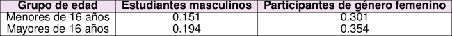

Por ejemplo, el 15.1% de los integrantes son estudiantes masculinos menores de 16 años. Según el cuadro, ¿cuál es la probabilidad de que al escoger una persona al azar pertenezca al grupo de los estudiantes masculinos, si ya se sabe que hace parte del grupo de mayores de 16 años?

## Answerlist

- 0.194/0.452
- 0.194/0.548
- 0.548/0.194
- 0.151/0.548

# Solution

Para resolver este problema de **probabilidad condicional**, necesitamos aplicar correctamente la fórmula de probabilidad condicional y trabajar con la información de la tabla de contingencia.

### Paso 1:

Identificar el tipo de problema y la fórmula Este es un problema de **probabilidad condicional**, donde buscamos:

$$P(\text{estudiantes masculinos} |
\text{mayores de 16 años})$$

La fórmula de probabilidad condicional es:
$$P(A|B) = \frac{P(A \cap B)}{P(B)}$$

Donde:

- $A$ = evento de interés: estudiantes masculinos
- $B$ = condición dada: mayores de 16 años
- $P(A \cap B)$ = probabilidad de que ocurran ambos eventos simultáneamente
- $P(B)$ = probabilidad marginal de la condición

### Paso 2:

Extraer información de la tabla de contingencia. De la tabla podemos obtener las siguientes **probabilidades conjuntas**:

- P(menores de 16 años $\cap$ estudiantes masculinos) = 0.151
- P(menores de 16 años $\cap$ participantes de género femenino) = 0.301
- P(mayores de 16 años $\cap$ estudiantes masculinos) = 0.194
- P(mayores de 16 años $\cap$ participantes de género femenino) = 0.354

### Paso 3:

Calcular probabilidades marginales Las **probabilidades marginales** se obtienen sumando las probabilidades conjuntas:

**Por género:**

- P(estudiantes masculinos) = 0.151 + 0.194 = 0.345
- P(participantes de género femenino) = 0.301 + 0.354 = 0.655

**Por edad:**

- P(menores de 16 años) = 0.151 + 0.301 = 0.452
- P(mayores de 16 años) = 0.194 + 0.354 = 0.548

### Paso 4:

Aplicar la fórmula para nuestro problema específico Para nuestro problema:

$$P(\text{estudiantes masculinos} |
\text{mayores de 16 años}) = \frac{P(\text{estudiantes masculinos} \cap
\text{mayores de 16 años})}{P(\text{mayores de 16 años})}$$

Sustituyendo los valores de la tabla:
$$P(\text{estudiantes masculinos} | \text{mayores
de 16 años}) = \frac{0.194}{0.548}$$

### Paso 5:

Verificación y análisis de distractores

**Análisis de errores conceptuales comunes (distractores):**

1. **0.194/0.452**: Error de **condición incorrecta** - usar el numerador correcto pero con una probabilidad marginal diferente como denominador
2. **0.151/0.548**: Error de **evento incorrecto** - usar el denominador correcto pero con una probabilidad conjunta diferente como numerador
3. **0.548/0.194**: Error de **intercambio P(A|B) con P(B|A)** - confundir la dirección de la probabilidad condicional invirtiendo numerador y denominador

### Conclusión

Por lo tanto, la probabilidad de que una persona pertenezca al grupo de estudiantes masculinos, dado que es mayores de 16 años, es **0.194/0.548**.

Esta respuesta tiene sentido porque:

- El resultado está entre 0 y 1 (como toda probabilidad)
- El numerador representa la intersección de los dos eventos
- El denominador representa la probabilidad de la condición dada
- La interpretación es coherente con el contexto del problema

## Answerlist

- Falso
- Verdadero
- Falso
- Falso

# Meta-information

exname: probabilidad_condicional_tabla_contingencia_corregido extype: schoice exsolution: 0100 exshuffle: TRUE exsection: Probabilidad|Probabilidad condicional|Tablas de contingencia|Razonamiento matemático exextra[Type]: Cálculo exextra[Program]: R exextra[Language]: es exextra[Level]: 3